# Analyse complète : Relation entre Taux de Natalité et Taux d’Urbanisation

Mohamed Amine Mazzez

2025-12-27

```r
# Chargement des packages nécessaires
knitr::opts_chunk$set(echo = TRUE, fig.path = "fig/")
library(knitr)
```

# 1. Présentation des données et objectifs

**Contexte :** Dans ce projet de statistique, nous étudions la relation entre le taux de natalité et le taux d’urbanisation pour 14 unités statistiques (pays ou régions).

**Variables :**

- **Taux de natalité** : nombre de naissances rapporté à la population (en %)
- **Taux d’urbanisation** : proportion de population en zone urbaine (en %)

**Objectifs de l’étude :**

1. Décrire la distribution des taux de natalité et d’urbanisation
2. Étudier la corrélation entre ces deux variables
3. Ajuster et valider un modèle de régression linéaire simple

# 2. Importation et préparation des données

```r
# Définir le répertoire de travail (à adapter selon votre configuration)
setwd("~/Desktop/R-stat/TP-1")

# Importation du fichier CSV
don <- read.csv2("don_mls.csv", header = TRUE, sep = ";", dec = ",")

# Renommage des colonnes pour simplifier
names(don) <- c("natalite", "urbanisation")

# Conversion en numérique
don$natalite      <- as.numeric(as.character(don$natalite))
don$urbanisation  <- as.numeric(as.character(don$urbanisation))

# Affichage des premières lignes
kable(head(don, 14), caption = "Tableau complet des données")
```

Tableau complet des données

| natalite | urbanisation |
| --- | --- |
| 16.2 | 55.0 |
| 30.5 | 27.3 |
| 16.9 | 33.3 |
| 16.0 | 56.5 |
| 40.2 | 11.5 |
| 38.4 | 14.2 |
| 41.3 | 13.9 |
| 43.9 | 19.0 |
| 28.3 | 33.1 |
| 33.9 | 43.2 |
| 44.2 | 28.5 |
| 24.6 | 6.8 |
| 28.0 | 37.7 |
| 33.1 | 37.1 |

```r
# Résumé statistique rapide
summary(don)
```

```
##     natalite      urbanisation
##  Min.   :16.00   Min.   : 6.80
##  1st Qu.:25.45   1st Qu.:15.40
##  Median :31.80   Median :30.80
##  Mean   :31.11   Mean   :29.79
##  3rd Qu.:39.75   3rd Qu.:37.55
##  Max.   :44.20   Max.   :56.50
```

# 3. Analyse descriptive univariée

```r
# Calcul des statistiques descriptives pour chaque variable

# Natalité
moy_nat <- mean(don$natalite)
med_nat <- median(don$natalite)
sd_nat  <- sd(don$natalite)
min_nat <- min(don$natalite)
max_nat <- max(don$natalite)

# Urbanisation
moy_urb <- mean(don$urbanisation)
med_urb <- median(don$urbanisation)
sd_urb  <- sd(don$urbanisation)
min_urb <- min(don$urbanisation)
max_urb <- max(don$urbanisation)

# Affichage formaté
cat("=== TAUX DE NATALITE ===\n")
```

```
## === TAUX DE NATALITE ===
```

```r
cat("Moyenne:", round(moy_nat,2), "% | Médiane:", round(med_nat,2), "%\n")
```

```
## Moyenne: 31.11 % | Médiane: 31.8 %
```

```r
cat("Min:", round(min_nat,2), "% | Max:", round(max_nat,2), "%\n")
```

```
## Min: 16 % | Max: 44.2 %
```

```r
cat("Écart-type:", round(sd_nat,2), "%\n\n")
```

```
## Écart-type: 10 %
```

```r
cat("=== TAUX D'URBANISATION ===\n")
```

```
## === TAUX D'URBANISATION ===
```

```r
cat("Moyenne:", round(moy_urb,2), "% | Médiane:", round(med_urb,2), "%\n")
```

```
## Moyenne: 29.79 % | Médiane: 30.8 %
```

```r
cat("Min:", round(min_urb,2), "% | Max:", round(max_urb,2), "%\n")
```

```
## Min: 6.8 % | Max: 56.5 %
```

```r
cat("Écart-type:", round(sd_urb,2), "%\n")
```

```
## Écart-type: 15.57 %
```

## 3.1 Histogrammes

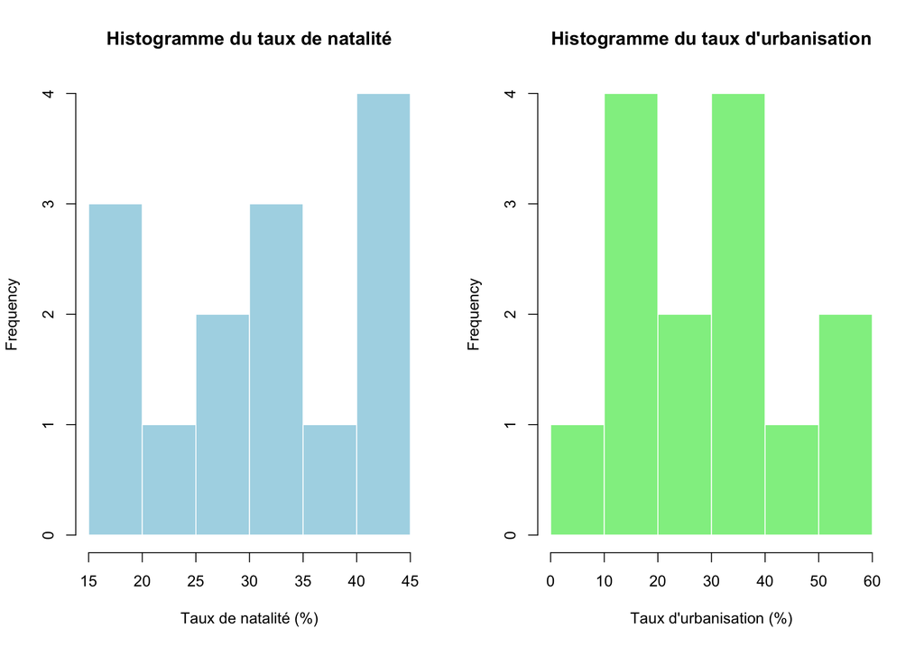

Histogrammes des deux variables

```r
par(mfrow=c(1,2))

hist(don$natalite,
     main="Histogramme du taux de natalité",
     xlab="Taux de natalité (%)",
     col="lightblue",
     border="white")

hist(don$urbanisation,
     main="Histogramme du taux d'urbanisation",
     xlab="Taux d'urbanisation (%)",
     col="lightgreen",
     border="white")
```

```r
par(mfrow=c(1,1))
```

**Interprétation :** Les histogrammes montrent que le taux de natalité présente une distribution étalée entre 16% et 44%, tandis que l’urbanisation varie principalement entre 10% et 60%.

## 3.2 Boxplots

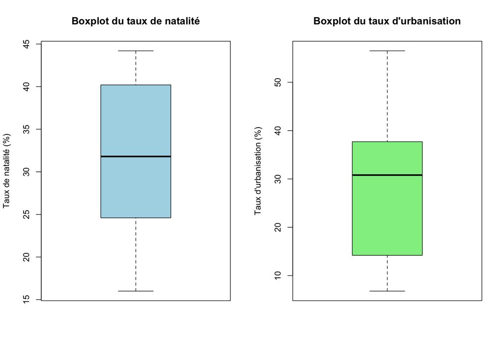

Boxplots des deux variables

```r
par(mfrow=c(1,2))

boxplot(don$natalite,
        main="Boxplot du taux de natalité",
        ylab="Taux de natalité (%)",
        col="lightblue")

boxplot(don$urbanisation,
        main="Boxplot du taux d'urbanisation",
        ylab="Taux d'urbanisation (%)",
        col="lightgreen")
```

```r
par(mfrow=c(1,1))
```

**Interprétation :** Les boxplots révèlent une dispersion modérée pour les deux variables, sans valeurs aberrantes extrêmes (outliers). La médiane de la natalité se situe autour de 32%, celle de l’urbanisation autour de 30%.

# 4. Analyse bivariée et corrélation

## 4.1 Coefficient de corrélation

```r
# Corrélation de Pearson
r_pearson <- cor(don$natalite, don$urbanisation, method="pearson")
test_cor  <- cor.test(don$natalite, don$urbanisation, method="pearson")

cat("Coefficient de corrélation de Pearson : r =", round(r_pearson,3), "\n")
```

```
## Coefficient de corrélation de Pearson : r = -0.621
```

```r
cat("p-value du test de corrélation :", format(test_cor$p.value, digits=4), "\n")
```

```
## p-value du test de corrélation : 0.01774
```

```r
cat("Intervalle de confiance 95% :", round(test_cor$conf.int[1],3), "à", round(test_cor$conf.int[2],3), "\n")
```

```
## Intervalle de confiance 95% : -0.866 à -0.135
```

**Interprétation :** La corrélation est **négative et forte** (r ≈ -0.621), ce qui suggère qu’une augmentation du taux d’urbanisation est associée à une diminution du taux de natalité. Le test est statistiquement significatif (p < 0.05).

## 4.2 Nuage de points

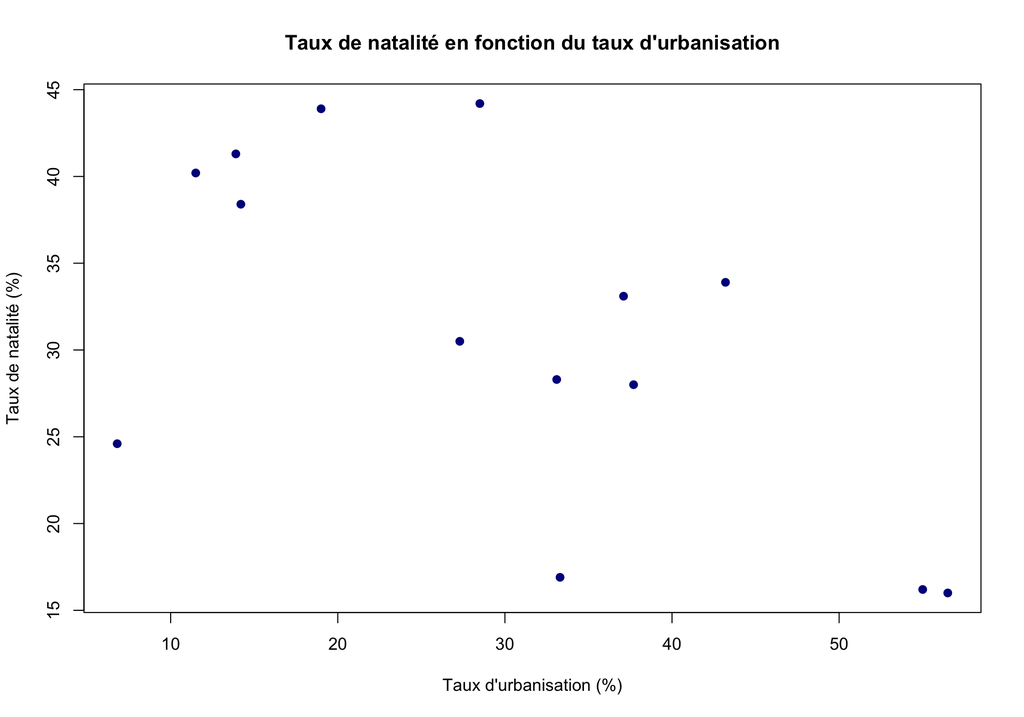

Nuage de points : Natalité en fonction de l’Urbanisation

```r
plot(don$urbanisation, don$natalite,
     main="Taux de natalité en fonction du taux d'urbanisation",
     pch=19,
     col="darkblue",
     xlab="Taux d'urbanisation (%)",
     ylab="Taux de natalité (%)")
```

**Interprétation :** Le nuage de points confirme visuellement la tendance négative observée dans la corrélation.

# 5. Modèle de régression linéaire

## 5.1 Ajustement du modèle

```r
# Ajustement du modèle linéaire
mod_lin <- lm(natalite ~ urbanisation, data = don)

# Résumé complet
summary(mod_lin)
```

```
##
## Call:
## lm(formula = natalite ~ urbanisation, data = don)
##
## Residuals:
##      Min       1Q   Median       3Q      Max
## -15.6782  -3.7413   0.5601   4.6440  12.5772
##
## Coefficients:
##              Estimate Std. Error t value Pr(>|t|)
## (Intercept)   42.9905     4.8454   8.872 1.28e-06 ***
## urbanisation  -0.3989     0.1453  -2.746   0.0177 *
## ---
## Signif. codes:  0 '***' 0.001 '**' 0.01 '*' 0.05 '.' 0.1 ' ' 1
##
## Residual standard error: 8.154 on 12 degrees of freedom
## Multiple R-squared:  0.3859, Adjusted R-squared:  0.3347
## F-statistic:  7.54 on 1 and 12 DF,  p-value: 0.01774
```

```r
# Extraction des coefficients
a <- coef(mod_lin)[1]  # Intercept
b <- coef(mod_lin)[2]  # Pente
R2 <- summary(mod_lin)$r.squared
p_pente <- summary(mod_lin)$coefficients[2,4]

cat("\n=== RÉSULTATS DU MODÈLE ===\n")
```

```
##
## === RÉSULTATS DU MODÈLE ===
```

```r
cat("Équation : natalité =", round(a,3), "+", round(b,3), "× urbanisation\n")
```

```
## Équation : natalité = 42.991 + -0.399 × urbanisation
```

```r
cat("R² =", round(R2,3), "(", round(100*R2,1), "% de variance expliquée)\n")
```

```
## R² = 0.386 ( 38.6 % de variance expliquée)
```

```r
cat("p-value de la pente =", format(p_pente, digits=4), "\n")
```

```
## p-value de la pente = 0.01774
```

**Interprétation principale :**

- Le modèle explique environ **38.6%** de la variabilité du taux de natalité
- La pente est **significativement différente de zéro** (p < 0.05)
- Une augmentation de 1 point de pourcentage du taux d’urbanisation est associée à une diminution moyenne de **0.399** points du taux de natalité

## 5.2 Visualisation de la régression

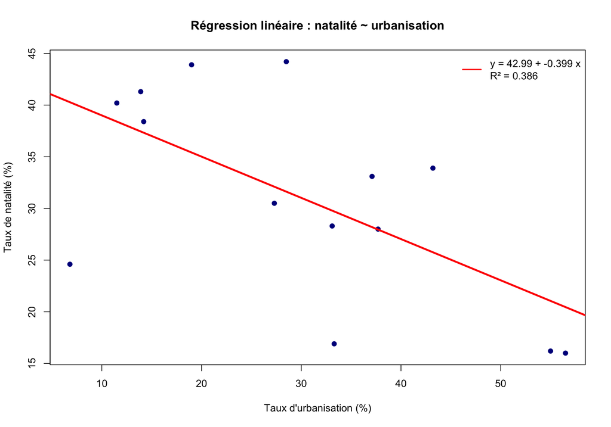

Régression linéaire avec droite ajustée

```r
plot(don$urbanisation, don$natalite,
     pch=19,
     col="darkblue",
     xlab="Taux d'urbanisation (%)",
     ylab="Taux de natalité (%)",
     main="Régression linéaire : natalité ~ urbanisation")

abline(mod_lin, col="red", lwd=3)

# Ajout d'une légende
legend("topright",
       legend=paste("y =", round(a,2), "+", round(b,3), "x\nR² =", round(R2,3)),
       col="red",
       lwd=2,
       bty="n")
```